# **Customer Churn Prediction**

**Context**

AlphaCom, a leading telecommunications provider, has recently experienced a concerning rise in customer churn despite offering competitive services and a wide product portfolio. This increase is directly impacting revenue and undermining brand reputation in an intensely competitive market. Traditional retention strategies have proven inadequate because customer churn is influenced by a complex mix of factors, including service usage, billing preferences, contract types, and demographics. Without clear insights into these patterns, the company is left reacting to churn instead of preventing it.

**Objective**

As a data scientist at AlphaCom, you are tasked with developing a predictive model to identify customers at high risk of churn and uncover the key factors driving their decisions. Solving this problem will enable the company to proactively design targeted retention strategies, reduce churn-related losses, and improve customer lifetime value, ultimately safeguarding revenue and strengthening AlphaCom’s competitive position.

```python
import warnings

warnings.filterwarnings("ignore")

# Libraries to help with reading and manipulating data
import numpy as np
import pandas as pd

# Library to split data
from sklearn.model_selection import train_test_split

# libaries to help with data visualization
import matplotlib.pyplot as plt
import seaborn as sns

# Removes the limit for the number of displayed columns
pd.set_option("display.max_columns", None)
# Sets the limit for the number of displayed rows
pd.set_option("display.max_rows", 100)


# Libraries different ensemble classifiers
from sklearn.ensemble import (
    BaggingRegressor,
    RandomForestRegressor,
    AdaBoostRegressor,
    GradientBoostingRegressor,
    StackingRegressor,
)

from xgboost import XGBRegressor
from sklearn.tree import DecisionTreeRegressor

# Libraries to get different metric scores
from sklearn import metrics
from sklearn.metrics import (
    confusion_matrix,
    accuracy_score,
    precision_score,
    recall_score,
    f1_score,
)

# To tune different models
from sklearn.model_selection import GridSearchCV
from sklearn.preprocessing import StandardScaler

sc = StandardScaler()
```

**Loading Data**

```python
Customer_Churn = pd.read_csv("/content/customer_churn.csv")
```

```python
Data = Customer_Churn.copy()
```

**Overview**

```python
Data.head()
```

|  | gender | SeniorCitizen | Partner | Dependents | tenure | PhoneService | MultipleLines | InternetService | OnlineSecurity | OnlineBackup | DeviceProtection | TechSupport | StreamingTV | StreamingMovies | Contract | PaperlessBilling | PaymentMethod | MonthlyCharges | TotalCharges | Churn |
| --- | --- | --- | --- | --- | --- | --- | --- | --- | --- | --- | --- | --- | --- | --- | --- | --- | --- | --- | --- | --- |
| 0 | Female | 0 | Yes | No | 1.0 | No | No phone service | DSL | No | Yes | No | No | No | No | Month-to-month | Yes | Electronic check | $29.85 | $29.85 | No |
| 1 | Male | 0 | No | No | 34.0 | Yes | No | DSL | Yes | No | Yes | No | No | No | One year | No | Mailed Check | $56.95 | $1889.5 | NO |
| 2 | Male | 0 | No | No | 2.0 | Yes | No | DSL | Yes | Yes | No | No | No | No | Month-to-month | Yes | Mailed check | $53.85 | $108.15 | YES |
| 3 | Male | 0 | No | No | 45.0 | No | No phone service | DSL | Yes | No | Yes | Yes | No | No | One year | No | bank transfer (automatic) | $42.3 | $1840.75 | No |
| 4 | Female | 0 | No | No | 2.0 | Yes | No | Fiber optic | No | No | No | No | No | No | Month-to-month | Yes | ELECTRONIC CHECK | $70.7 | $nan | yes |

**Shape of the Data**

```python
print(f"There are {Data.shape[0]} rows and {Data.shape[1]} columns.")
```

```
There are 12055 rows and 20 columns.
```

**Data types of all columns**

```python
Data.info()
```

```
<class 'pandas.core.frame.DataFrame'>
RangeIndex: 12055 entries, 0 to 12054
Data columns (total 20 columns):
 #   Column            Non-Null Count  Dtype
---  ------            --------------  -----
 0   gender            12055 non-null  object
 1   SeniorCitizen     12055 non-null  int64
 2   Partner           12055 non-null  object
 3   Dependents        12055 non-null  object
 4   tenure            11451 non-null  float64
 5   PhoneService      12055 non-null  object
 6   MultipleLines     12055 non-null  object
 7   InternetService   12055 non-null  object
 8   OnlineSecurity    12055 non-null  object
 9   OnlineBackup      12055 non-null  object
 10  DeviceProtection  12055 non-null  object
 11  TechSupport       12055 non-null  object
 12  StreamingTV       12055 non-null  object
 13  StreamingMovies   12055 non-null  object
 14  Contract          12055 non-null  object
 15  PaperlessBilling  12055 non-null  object
 16  PaymentMethod     12055 non-null  object
 17  MonthlyCharges    12055 non-null  object
 18  TotalCharges      12055 non-null  object
 19  Churn             12055 non-null  object
dtypes: float64(1), int64(1), object(18)
memory usage: 1.8+ MB
```

Monthly charges and Total charges are showing object type but it should be float type and Churn is also showing object type but it should be binary type.

```python
Data.Churn.unique()
```

```
array(['  No  ', 'NO', 'YES', 'yes', 'Yes', 'No', 'no', '  Yes  '],
      dtype=object)
```

```python
Data['Churn'] = Data['Churn'].astype(str).str.lower().str.strip().replace({'yes': 1,'no': 0})
```

```python
dollar_prices = Data[Data['MonthlyCharges'].str.contains(r'\$', na=False)]['MonthlyCharges'].reset_index(drop=True)
pound_prices  = Data[Data['MonthlyCharges'].str.contains(r'£', na=False)]['MonthlyCharges'].reset_index(drop=True)
price_table = pd.concat([dollar_prices, pound_prices], axis=1)
price_table.columns = ['Dollar ($)', 'Pound (£)']
price_table
```

|  | Dollar ($) | Pound (£) |
| --- | --- | --- |
| 0 | $29.85 | £49.05 |
| 1 | $56.95 | £25.7 |
| 2 | $53.85 | £69.5 |
| 3 | $42.3 | £101.9 |
| 4 | $70.7 | £84.2 |
| ... | ... | ... |
| 11866 | $89.5 | NaN |
| 11867 | $74.7 | NaN |
| 11868 | $113.4 | NaN |
| 11869 | $99.65 | NaN |
| 11870 | $100.05 | NaN |

11871 rows × 2 columns

The significant difference between the number of entries with '$' (11871 rows) and '£' (183 rows) in 'MonthlyCharges' indicates a likely data entry error. So we will assume everything is in Dollar and proceed.

```python
dollar_prices = Data[Data['TotalCharges'].str.contains(r'\$', na=False)]['TotalCharges'].reset_index(drop=True)
pound_prices  = Data[Data['TotalCharges'].str.contains(r'£', na=False)]['TotalCharges'].reset_index(drop=True)
price_table = pd.concat([dollar_prices, pound_prices], axis=1)
price_table.columns = ['Dollar ($)', 'Pound (£)']
price_table
```

|  | Dollar ($) | Pound (£) |
| --- | --- | --- |
| 0 | $29.85 | £49.05 |
| 1 | $1889.5 | £1188.2 |
| 2 | $108.15 | £1071.4 |
| 3 | $1840.75 | £2681.15 |
| 4 | $nan | £nan |
| ... | ... | ... |
| 11866 | $573.3 | NaN |
| 11867 | $nan | NaN |
| 11868 | $8164.1 | NaN |
| 11869 | $5497.05 | NaN |
| 11870 | $6034.85 | NaN |

11871 rows × 2 columns

The significant difference between the number of entries with '$' (11871 rows) and '£' (183 rows) in 'TotalCharges' indicates a likely data entry error. So we will assume everything is in Dollar and proceed.

**Correcting data types**

```python
Data['MonthlyCharges'] = Data['MonthlyCharges'].apply(lambda X: X.replace("$",""))
Data['MonthlyCharges'] = Data['MonthlyCharges'].apply(lambda X: X.replace("£",""))
Data['MonthlyCharges'] = Data['MonthlyCharges'].astype("float")
Data['TotalCharges'] = Data['TotalCharges'].apply(lambda X: X.replace("$",""))
Data['TotalCharges'] = Data['TotalCharges'].apply(lambda X: X.replace("£",""))
Data['TotalCharges'] = Data['TotalCharges'].astype("float")
```

```python
Data.info()
```

```
<class 'pandas.core.frame.DataFrame'>
RangeIndex: 12055 entries, 0 to 12054
Data columns (total 20 columns):
 #   Column            Non-Null Count  Dtype
---  ------            --------------  -----
 0   gender            12055 non-null  object
 1   SeniorCitizen     12055 non-null  int64
 2   Partner           12055 non-null  object
 3   Dependents        12055 non-null  object
 4   tenure            11451 non-null  float64
 5   PhoneService      12055 non-null  object
 6   MultipleLines     12055 non-null  object
 7   InternetService   12055 non-null  object
 8   OnlineSecurity    12055 non-null  object
 9   OnlineBackup      12055 non-null  object
 10  DeviceProtection  12055 non-null  object
 11  TechSupport       12055 non-null  object
 12  StreamingTV       12055 non-null  object
 13  StreamingMovies   12055 non-null  object
 14  Contract          12055 non-null  object
 15  PaperlessBilling  12055 non-null  object
 16  PaymentMethod     12055 non-null  object
 17  MonthlyCharges    11754 non-null  float64
 18  TotalCharges      10850 non-null  float64
 19  Churn             12055 non-null  int64
dtypes: float64(3), int64(2), object(15)
memory usage: 1.8+ MB
```

```python
Data.tenure.unique()
```

```
array([ 1., 34.,  2., 45.,  8., 22., 10., 28., 62., 13., 16., 58., 49.,
       25., 69., 52., 71., 21., nan, 12., 30., 72., 17., 27.,  5., 46.,
       11., 70., 63., 43., 15., 60., 18., 66., 47.,  9.,  3., 31., 50.,
       64., 56.,  7., 42., 35., 48., 29., 65., 38., 68., 32., 55., 37.,
       36., 41.,  6.,  4., 33., 67., 23., 57., 61., 14., 20., 53., 40.,
       59., 24., 44., 19., 54., 51., 26.,  0., 39., -1., 73., -2., 74.,
       -3.])
```

The 'tenure' column contains negative values, which are likely data entry errors and can be problematic for analysis. To address this, these erroneous values will be replaced with NaN (Not a Number) and then imputed with the median of the 'tenure' column. This approach maintains data robustness by using a central tendency measure, minimizing the impact of outliers or incorrect entries.

```python
Data.loc[Data['tenure'] < 0, 'tenure'] = np.nan
Data['tenure'].fillna(Data['tenure'].median(), inplace=True)
```

**Check for Missing Values**

```python
Data.isnull().sum()
```

|  | 0 |
| --- | --- |
| gender | 0 |
| SeniorCitizen | 0 |
| Partner | 0 |
| Dependents | 0 |
| tenure | 0 |
| PhoneService | 0 |
| MultipleLines | 0 |
| InternetService | 0 |
| OnlineSecurity | 0 |
| OnlineBackup | 0 |
| DeviceProtection | 0 |
| TechSupport | 0 |
| StreamingTV | 0 |
| StreamingMovies | 0 |
| Contract | 0 |
| PaperlessBilling | 0 |
| PaymentMethod | 0 |
| MonthlyCharges | 301 |
| TotalCharges | 1205 |
| Churn | 0 |

**dtype:** int64

Lets fill missing values of monthly charges and total charges with median of respective column.

```python
Data['MonthlyCharges'].fillna(Data['MonthlyCharges'].median(), inplace=True)
Data['TotalCharges'].fillna(Data['TotalCharges'].median(), inplace=True)
```

```python
Data.isnull().sum()
```

|  | 0 |
| --- | --- |
| gender | 0 |
| SeniorCitizen | 0 |
| Partner | 0 |
| Dependents | 0 |
| tenure | 0 |
| PhoneService | 0 |
| MultipleLines | 0 |
| InternetService | 0 |
| OnlineSecurity | 0 |
| OnlineBackup | 0 |
| DeviceProtection | 0 |
| TechSupport | 0 |
| StreamingTV | 0 |
| StreamingMovies | 0 |
| Contract | 0 |
| PaperlessBilling | 0 |
| PaymentMethod | 0 |
| MonthlyCharges | 0 |
| TotalCharges | 0 |
| Churn | 0 |

**dtype:** int64

**Check for Duplicate values**

```python
Data.duplicated().sum()
```

```
np.int64(4)
```

```python
Data.drop_duplicates(inplace=True)
```

```python
Data.duplicated().sum()
```

```
np.int64(0)
```

**Statistical Summary**

```python
Data.describe(include="all").T
```

|  | count | unique | top | freq | mean | std | min | 25% | 50% | 75% | max |
| --- | --- | --- | --- | --- | --- | --- | --- | --- | --- | --- | --- |
| gender | 12051 | 2 | Male | 6709 | NaN | NaN | NaN | NaN | NaN | NaN | NaN |
| SeniorCitizen | 12051.0 | NaN | NaN | NaN | 0.117999 | 0.32262 | 0.0 | 0.0 | 0.0 | 0.0 | 1.0 |
| Partner | 12051 | 2 | No | 6987 | NaN | NaN | NaN | NaN | NaN | NaN | NaN |
| Dependents | 12051 | 2 | No | 8844 | NaN | NaN | NaN | NaN | NaN | NaN | NaN |
| tenure | 12051.0 | NaN | NaN | NaN | 31.389179 | 24.175096 | 0.0 | 8.0 | 28.0 | 53.0 | 74.0 |
| PhoneService | 12051 | 2 | Yes | 10743 | NaN | NaN | NaN | NaN | NaN | NaN | NaN |
| MultipleLines | 12051 | 3 | Yes | 5609 | NaN | NaN | NaN | NaN | NaN | NaN | NaN |
| InternetService | 12051 | 3 | Fiber optic | 4876 | NaN | NaN | NaN | NaN | NaN | NaN | NaN |
| OnlineSecurity | 12051 | 3 | No | 6310 | NaN | NaN | NaN | NaN | NaN | NaN | NaN |
| OnlineBackup | 12051 | 3 | No | 5981 | NaN | NaN | NaN | NaN | NaN | NaN | NaN |
| DeviceProtection | 12051 | 3 | Yes | 4634 | NaN | NaN | NaN | NaN | NaN | NaN | NaN |
| TechSupport | 12051 | 3 | No | 6220 | NaN | NaN | NaN | NaN | NaN | NaN | NaN |
| StreamingTV | 12051 | 3 | No | 4999 | NaN | NaN | NaN | NaN | NaN | NaN | NaN |
| StreamingMovies | 12051 | 3 | No | 5056 | NaN | NaN | NaN | NaN | NaN | NaN | NaN |
| Contract | 12051 | 3 | Month-to-month | 6551 | NaN | NaN | NaN | NaN | NaN | NaN | NaN |
| PaperlessBilling | 12051 | 2 | Yes | 6158 | NaN | NaN | NaN | NaN | NaN | NaN | NaN |
| PaymentMethod | 12051 | 20 | electronic check | 860 | NaN | NaN | NaN | NaN | NaN | NaN | NaN |
| MonthlyCharges | 12051.0 | NaN | NaN | NaN | 64.546602 | 29.971038 | 15.29 | 34.395 | 71.35 | 89.085 | 121.67 |
| TotalCharges | 12051.0 | NaN | NaN | NaN | 2196.018658 | 2180.000353 | -197.0 | 488.45 | 1328.75 | 3602.175 | 9039.92 |
| Churn | 12051.0 | NaN | NaN | NaN | 0.282383 | 0.450177 | 0.0 | 0.0 | 0.0 | 1.0 | 1.0 |

As we can see, there are still a few records in the 'TotalCharges' column that are negative. Let's correct this by replacing these negative values with NaN and then filling them with the median of the column.

```python
Data.loc[Data['TotalCharges'] < 0, 'TotalCharges'] = np.nan
Data['TotalCharges'].fillna(Data['TotalCharges'].median(), inplace=True)
```

```python
Data.describe(include='all').T
```

|  | count | unique | top | freq | mean | std | min | 25% | 50% | 75% | max |
| --- | --- | --- | --- | --- | --- | --- | --- | --- | --- | --- | --- |
| gender | 12051 | 2 | Male | 6709 | NaN | NaN | NaN | NaN | NaN | NaN | NaN |
| SeniorCitizen | 12051.0 | NaN | NaN | NaN | 0.117999 | 0.32262 | 0.0 | 0.0 | 0.0 | 0.0 | 1.0 |
| Partner | 12051 | 2 | No | 6987 | NaN | NaN | NaN | NaN | NaN | NaN | NaN |
| Dependents | 12051 | 2 | No | 8844 | NaN | NaN | NaN | NaN | NaN | NaN | NaN |
| tenure | 12051.0 | NaN | NaN | NaN | 31.389179 | 24.175096 | 0.0 | 8.0 | 28.0 | 53.0 | 74.0 |
| PhoneService | 12051 | 2 | Yes | 10743 | NaN | NaN | NaN | NaN | NaN | NaN | NaN |
| MultipleLines | 12051 | 3 | Yes | 5609 | NaN | NaN | NaN | NaN | NaN | NaN | NaN |
| InternetService | 12051 | 3 | Fiber optic | 4876 | NaN | NaN | NaN | NaN | NaN | NaN | NaN |
| OnlineSecurity | 12051 | 3 | No | 6310 | NaN | NaN | NaN | NaN | NaN | NaN | NaN |
| OnlineBackup | 12051 | 3 | No | 5981 | NaN | NaN | NaN | NaN | NaN | NaN | NaN |
| DeviceProtection | 12051 | 3 | Yes | 4634 | NaN | NaN | NaN | NaN | NaN | NaN | NaN |
| TechSupport | 12051 | 3 | No | 6220 | NaN | NaN | NaN | NaN | NaN | NaN | NaN |
| StreamingTV | 12051 | 3 | No | 4999 | NaN | NaN | NaN | NaN | NaN | NaN | NaN |
| StreamingMovies | 12051 | 3 | No | 5056 | NaN | NaN | NaN | NaN | NaN | NaN | NaN |
| Contract | 12051 | 3 | Month-to-month | 6551 | NaN | NaN | NaN | NaN | NaN | NaN | NaN |
| PaperlessBilling | 12051 | 2 | Yes | 6158 | NaN | NaN | NaN | NaN | NaN | NaN | NaN |
| PaymentMethod | 12051 | 20 | electronic check | 860 | NaN | NaN | NaN | NaN | NaN | NaN | NaN |
| MonthlyCharges | 12051.0 | NaN | NaN | NaN | 64.546602 | 29.971038 | 15.29 | 34.395 | 71.35 | 89.085 | 121.67 |
| TotalCharges | 12051.0 | NaN | NaN | NaN | 2212.849369 | 2167.873866 | 0.0 | 539.95 | 1328.75 | 3602.175 | 9039.92 |
| Churn | 12051.0 | NaN | NaN | NaN | 0.282383 | 0.450177 | 0.0 | 0.0 | 0.0 | 1.0 | 1.0 |

```python
for col in Data.select_dtypes(include='object').columns:
    print(f"Column: {col}")
    print(Data[col].unique())
    print("\n" + "-"*50 + "\n")
```

```
Column: gender
['Female' 'Male']

--------------------------------------------------

Column: Partner
['Yes' 'No']

--------------------------------------------------

Column: Dependents
['No' 'Yes']

--------------------------------------------------

Column: PhoneService
['No' 'Yes']

--------------------------------------------------

Column: MultipleLines
['No phone service' 'No' 'Yes']

--------------------------------------------------

Column: InternetService
['DSL' 'Fiber optic' 'No']

--------------------------------------------------

Column: OnlineSecurity
['No' 'Yes' 'No internet service']

--------------------------------------------------

Column: OnlineBackup
['Yes' 'No' 'No internet service']

--------------------------------------------------

```

[output cut: 26 more lines]

```
['Yes' 'No']

--------------------------------------------------

Column: PaymentMethod
['Electronic check' 'Mailed Check' 'Mailed check'
 'bank transfer (automatic)' 'ELECTRONIC CHECK' '  Electronic check  '
 'credit card (automatic)' 'BANK TRANSFER (AUTOMATIC)'
 'Credit card (automatic)' 'CREDIT CARD (AUTOMATIC)'
 'Bank transfer (automatic)' 'Electronic Check' 'MAILED CHECK'
 '  Credit card (automatic)  ' 'Bank Transfer (Automatic)'
 '  Mailed check  ' '  Bank transfer (automatic)  '
 'Credit Card (Automatic)' 'electronic check' 'mailed check']

--------------------------------------------------
```

There are some unwanted spaces in the 'PaymentMethod' column. We will remove that.

```python
Data['PaymentMethod'] = Data['PaymentMethod'].astype(str).str.lower().str.strip()
```

```python
for col in Data.select_dtypes(include='object').columns:
    print(f"Column: {col}")
    print(Data[col].unique())
    print("\n" + "-"*50 + "\n")
```

```
Column: gender
['Female' 'Male']

--------------------------------------------------

Column: Partner
['Yes' 'No']

--------------------------------------------------

Column: Dependents
['No' 'Yes']

--------------------------------------------------

Column: PhoneService
['No' 'Yes']

--------------------------------------------------

Column: MultipleLines
['No phone service' 'No' 'Yes']

--------------------------------------------------

Column: InternetService
['DSL' 'Fiber optic' 'No']

--------------------------------------------------

Column: OnlineSecurity
['No' 'Yes' 'No internet service']

--------------------------------------------------

Column: OnlineBackup
['Yes' 'No' 'No internet service']

--------------------------------------------------

```

[output cut: 20 more lines]

```
Column: Contract
['Month-to-month' 'One year' 'Two year']

--------------------------------------------------

Column: PaperlessBilling
['Yes' 'No']

--------------------------------------------------

Column: PaymentMethod
['electronic check' 'mailed check' 'bank transfer (automatic)'
 'credit card (automatic)']

--------------------------------------------------
```

```python
Data.describe(include='all').T
```

|  | count | unique | top | freq | mean | std | min | 25% | 50% | 75% | max |
| --- | --- | --- | --- | --- | --- | --- | --- | --- | --- | --- | --- |
| gender | 12051 | 2 | Male | 6709 | NaN | NaN | NaN | NaN | NaN | NaN | NaN |
| SeniorCitizen | 12051.0 | NaN | NaN | NaN | 0.117999 | 0.32262 | 0.0 | 0.0 | 0.0 | 0.0 | 1.0 |
| Partner | 12051 | 2 | No | 6987 | NaN | NaN | NaN | NaN | NaN | NaN | NaN |
| Dependents | 12051 | 2 | No | 8844 | NaN | NaN | NaN | NaN | NaN | NaN | NaN |
| tenure | 12051.0 | NaN | NaN | NaN | 31.389179 | 24.175096 | 0.0 | 8.0 | 28.0 | 53.0 | 74.0 |
| PhoneService | 12051 | 2 | Yes | 10743 | NaN | NaN | NaN | NaN | NaN | NaN | NaN |
| MultipleLines | 12051 | 3 | Yes | 5609 | NaN | NaN | NaN | NaN | NaN | NaN | NaN |
| InternetService | 12051 | 3 | Fiber optic | 4876 | NaN | NaN | NaN | NaN | NaN | NaN | NaN |
| OnlineSecurity | 12051 | 3 | No | 6310 | NaN | NaN | NaN | NaN | NaN | NaN | NaN |
| OnlineBackup | 12051 | 3 | No | 5981 | NaN | NaN | NaN | NaN | NaN | NaN | NaN |
| DeviceProtection | 12051 | 3 | Yes | 4634 | NaN | NaN | NaN | NaN | NaN | NaN | NaN |
| TechSupport | 12051 | 3 | No | 6220 | NaN | NaN | NaN | NaN | NaN | NaN | NaN |
| StreamingTV | 12051 | 3 | No | 4999 | NaN | NaN | NaN | NaN | NaN | NaN | NaN |
| StreamingMovies | 12051 | 3 | No | 5056 | NaN | NaN | NaN | NaN | NaN | NaN | NaN |
| Contract | 12051 | 3 | Month-to-month | 6551 | NaN | NaN | NaN | NaN | NaN | NaN | NaN |
| PaperlessBilling | 12051 | 2 | Yes | 6158 | NaN | NaN | NaN | NaN | NaN | NaN | NaN |
| PaymentMethod | 12051 | 4 | electronic check | 4144 | NaN | NaN | NaN | NaN | NaN | NaN | NaN |
| MonthlyCharges | 12051.0 | NaN | NaN | NaN | 64.546602 | 29.971038 | 15.29 | 34.395 | 71.35 | 89.085 | 121.67 |
| TotalCharges | 12051.0 | NaN | NaN | NaN | 2212.849369 | 2167.873866 | 0.0 | 539.95 | 1328.75 | 3602.175 | 9039.92 |
| Churn | 12051.0 | NaN | NaN | NaN | 0.282383 | 0.450177 | 0.0 | 0.0 | 0.0 | 1.0 | 1.0 |

Now, the data appears to be thoroughly cleaned and consistent across all columns. We can confidently proceed with the Exploratory Data Analysis (EDA) phase.

# **Exploratory Data Analysis**

### **Univariate Analysis**

**1. Distribution of 'Churn'**

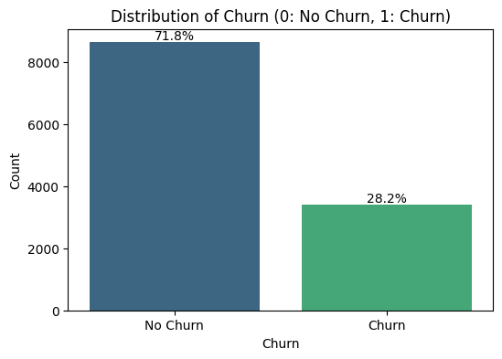

```python
plt.figure(figsize=(6, 4))
ax = sns.countplot(x='Churn', data=Data, palette='viridis')
plt.title('Distribution of Churn (0: No Churn, 1: Churn)')
plt.xlabel('Churn')
plt.ylabel('Count')
plt.xticks(ticks=[0, 1], labels=['No Churn', 'Churn'])

total = len(Data['Churn'])
for p in ax.patches:
    percentage = '{:.1f}%'.format(100 * p.get_height()/total)
    x = p.get_x() + p.get_width() / 2
    y = p.get_height()
    ax.annotate(percentage, (x, y), ha='center', va='bottom')

plt.show()
```

- Approximately 28% of the customers have churned (represented by '1'), while about 72% have not churned (represented by '0').

**2. Distribution of 'gender'**

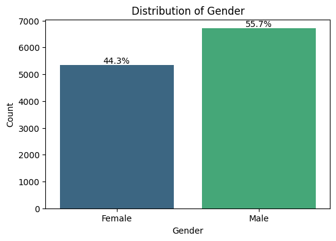

```python
plt.figure(figsize=(6, 4))
ax = sns.countplot(data=Data, x='gender', palette='viridis')
plt.title('Distribution of Gender')
plt.xlabel('Gender')
plt.ylabel('Count')

total = len(Data['gender'])
for p in ax.patches:
    percentage = '{:.1f}%'.format(100 * p.get_height()/total)
    x = p.get_x() + p.get_width() / 2
    y = p.get_height()
    ax.annotate(percentage, (x, y), ha='center', va='bottom')

plt.show()
```

- The gender distribution is nearly balanced, with slightly more males (55.7%) than females (44.3%) in the dataset.

**3. Distribution of 'SeniorCitizen'**

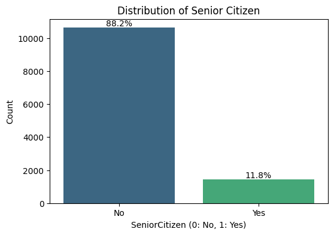

```python
plt.figure(figsize=(6, 4))
ax = sns.countplot(data=Data, x='SeniorCitizen', palette='viridis')
plt.title('Distribution of Senior Citizen')
plt.xlabel('SeniorCitizen (0: No, 1: Yes)')
plt.ylabel('Count')
plt.xticks(ticks=[0, 1], labels=['No', 'Yes'])

total = len(Data['SeniorCitizen'])
for p in ax.patches:
    percentage = '{:.1f}%'.format(100 * p.get_height()/total)
    x = p.get_x() + p.get_width() / 2
    y = p.get_height()
    ax.annotate(percentage, (x, y), ha='center', va='bottom')

plt.show()
```

**4. Distribution of 'Partner'**

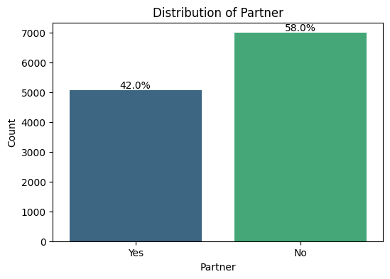

```python
plt.figure(figsize=(6, 4))
ax = sns.countplot(data=Data, x='Partner', palette='viridis')
plt.title('Distribution of Partner')
plt.xlabel('Partner')
plt.ylabel('Count')

total = len(Data['Partner'])
for p in ax.patches:
    percentage = '{:.1f}%'.format(100 * p.get_height()/total)
    x = p.get_x() + p.get_width() / 2
    y = p.get_height()
    ax.annotate(percentage, (x, y), ha='center', va='bottom')

plt.show()
```

- The plot shows that the majority of customers (58.0%) do not have a partner, while 42.0% do.

**5. Distribution of 'Dependents'**

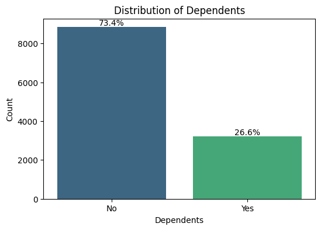

```python
plt.figure(figsize=(6, 4))
ax = sns.countplot(data=Data, x='Dependents', palette='viridis')
plt.title('Distribution of Dependents')
plt.xlabel('Dependents')
plt.ylabel('Count')

total = len(Data['Dependents'])
for p in ax.patches:
    percentage = '{:.1f}%'.format(100 * p.get_height()/total)
    x = p.get_x() + p.get_width() / 2
    y = p.get_height()
    ax.annotate(percentage, (x, y), ha='center', va='bottom')

plt.show()
```

- The plot shows that the majority of customers (73.4%) do not have dependents, while 26.6% do.

**6. Distribution of 'tenure'**

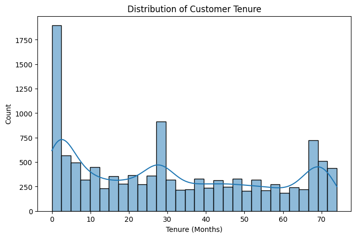

```python
plt.figure(figsize=(8, 5))
sns.histplot(Data['tenure'], bins=30, kde=True, palette='viridis')
plt.title('Distribution of Customer Tenure')
plt.xlabel('Tenure (Months)')
plt.ylabel('Count')
plt.show()
```

- The distribution of 'tenure' shows a bimodal shape, with a significant number of customers having very short tenure (around 0-5 months) and another peak for customers with longer tenure (around 65-70 months). This suggests that many customers either churn early or stay for a long time.

**7. Distribution of 'PhoneService'**

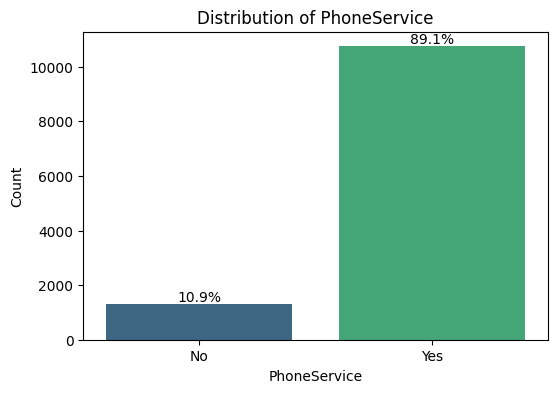

```python
plt.figure(figsize=(6, 4))
ax = sns.countplot(data=Data, x='PhoneService', palette='viridis')
plt.title('Distribution of PhoneService')
plt.xlabel('PhoneService')
plt.ylabel('Count')

total = len(Data['PhoneService'])
for p in ax.patches:
    percentage = '{:.1f}%'.format(100 * p.get_height()/total)
    x = p.get_x() + p.get_width() / 2
    y = p.get_height()
    ax.annotate(percentage, (x, y), ha='center', va='bottom')

plt.show()
```

- A significant majority of customers (89.1%) have phone service, while only (10.9%) do not.

**8. Distribution of 'MultipleLines'**

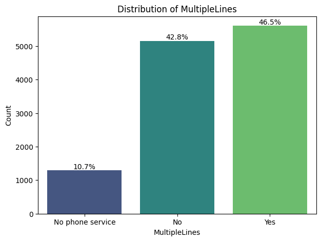

```python
plt.figure(figsize=(7, 5))
ax = sns.countplot(data=Data, x='MultipleLines', palette='viridis')
plt.title('Distribution of MultipleLines')
plt.xlabel('MultipleLines')
plt.ylabel('Count')

total = len(Data['MultipleLines'])
for p in ax.patches:
    percentage = '{:.1f}%'.format(100 * p.get_height()/total)
    x = p.get_x() + p.get_width() / 2
    y = p.get_height()
    ax.annotate(percentage, (x, y), ha='center', va='bottom')

plt.show()
```

**9. Distribution of 'InternetService'**

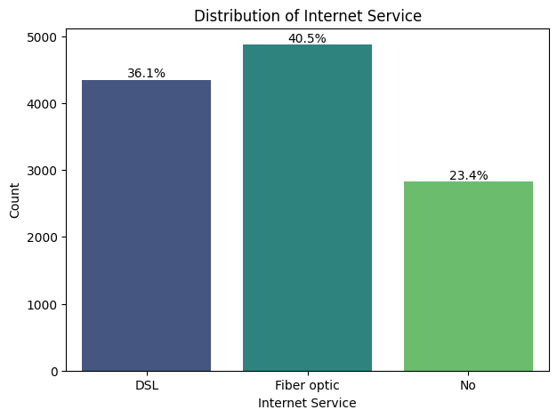

```python
plt.figure(figsize=(7, 5))
ax = sns.countplot(data=Data, x='InternetService', palette='viridis')
plt.title('Distribution of Internet Service')
plt.xlabel('Internet Service')
plt.ylabel('Count')

total = len(Data['InternetService'])
for p in ax.patches:
    percentage = '{:.1f}%'.format(100 * p.get_height()/total)
    x = p.get_x() + p.get_width() / 2
    y = p.get_height()
    ax.annotate(percentage, (x, y), ha='center', va='bottom')

plt.show()
```

- The 'Fiber optic' service has the highest number of customers, followed by 'DSL', and then a significant portion of customers with 'No' internet service.

**10. Distribution of 'OnlineSecurity'**

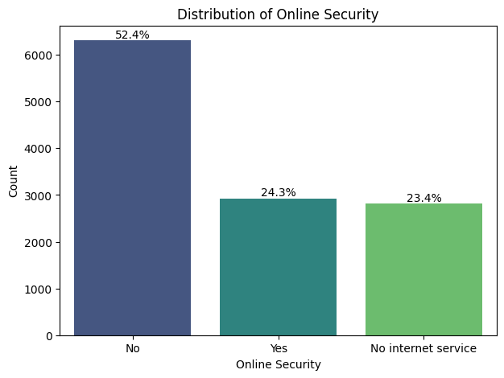

```python
plt.figure(figsize=(7, 5))
ax = sns.countplot(data=Data, x='OnlineSecurity', palette='viridis')
plt.title('Distribution of Online Security')
plt.xlabel('Online Security')
plt.ylabel('Count')

total = len(Data['OnlineSecurity'])
for p in ax.patches:
    percentage = '{:.1f}%'.format(100 * p.get_height()/total)
    x = p.get_x() + p.get_width() / 2
    y = p.get_height()
    ax.annotate(percentage, (x, y), ha='center', va='bottom')

plt.show()
```

- The 'No' category has the highest count, followed by 'Yes', and then 'No internet service'. This indicates that a large portion of customers do not have online security or do not have internet service at all.

**11. Distribution of 'OnlineBackup'**

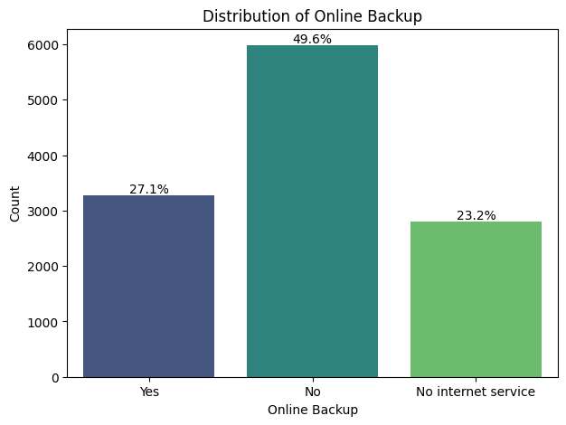

```python
plt.figure(figsize=(7, 5))
ax = sns.countplot(data=Data, x='OnlineBackup', palette='viridis')
plt.title('Distribution of Online Backup')
plt.xlabel('Online Backup')
plt.ylabel('Count')

total = len(Data['OnlineBackup'])
for p in ax.patches:
    percentage = '{:.1f}%'.format(100 * p.get_height()/total)
    x = p.get_x() + p.get_width() / 2
    y = p.get_height()
    ax.annotate(percentage, (x, y), ha='center', va='bottom')

plt.show()
```

- The 'No' category has the highest count, followed by 'Yes', and then 'No internet service'. This indicates that a large portion of customers do not have online backup or do not have internet service at all.

**12. Distribution of 'DeviceProtection'**

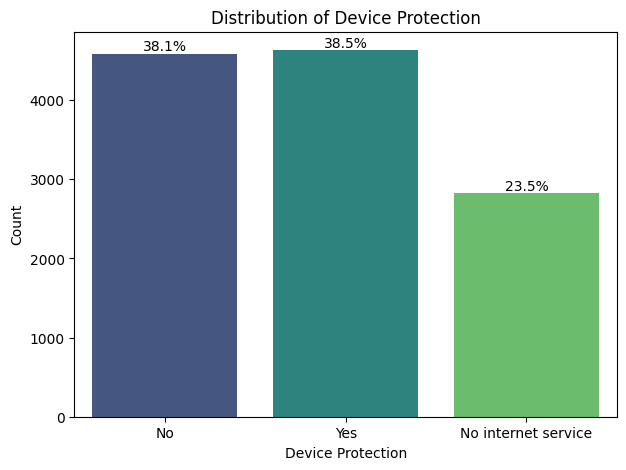

```python
plt.figure(figsize=(7, 5))
ax = sns.countplot(data=Data, x='DeviceProtection', palette='viridis')
plt.title('Distribution of Device Protection')
plt.xlabel('Device Protection')
plt.ylabel('Count')

total = len(Data['DeviceProtection'])
for p in ax.patches:
    percentage = '{:.1f}%'.format(100 * p.get_height()/total)
    x = p.get_x() + p.get_width() / 2
    y = p.get_height()
    ax.annotate(percentage, (x, y), ha='center', va='bottom')

plt.show()
```

- The 'Yes' category has the highest count, followed by 'No', and then 'No internet service'. This suggests that a considerable number of customers do not have device protection or do not have internet service at all.

**13. Distribution of 'TechSupport'**

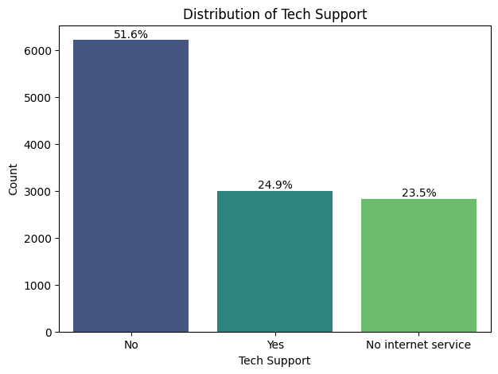

```python
plt.figure(figsize=(7, 5))
ax = sns.countplot(data=Data, x='TechSupport', palette='viridis')
plt.title('Distribution of Tech Support')
plt.xlabel('Tech Support')
plt.ylabel('Count')

total = len(Data['TechSupport'])
for p in ax.patches:
    percentage = '{:.1f}%'.format(100 * p.get_height()/total)
    x = p.get_x() + p.get_width() / 2
    y = p.get_height()
    ax.annotate(percentage, (x, y), ha='center', va='bottom')

plt.show()
```

- The 'No' category has the highest count, followed by 'Yes', and then 'No internet service'. This implies that a substantial number of customers either do not have technical support or do not have internet service at all.

**14. Distribution of 'StreamingTV'**

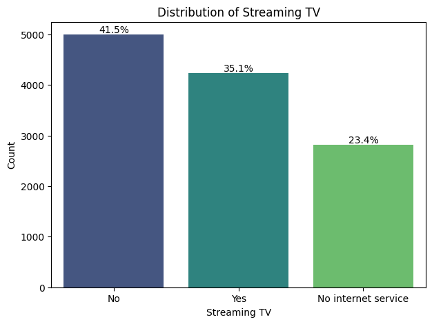

```python
plt.figure(figsize=(7, 5))
ax = sns.countplot(data=Data, x='StreamingTV', palette='viridis')
plt.title('Distribution of Streaming TV')
plt.xlabel('Streaming TV')
plt.ylabel('Count')

total = len(Data['StreamingTV'])
for p in ax.patches:
    percentage = '{:.1f}%'.format(100 * p.get_height()/total)
    x = p.get_x() + p.get_width() / 2
    y = p.get_height()
    ax.annotate(percentage, (x, y), ha='center', va='bottom')

plt.show()
```

- The distribution of 'StreamingTV' shows that the 'No' category has the highest count, followed by 'Yes', and then 'No internet service'. This suggests that a significant portion of customers do not subscribe to streaming TV services or do not have internet service at all.

**15. Distribution of 'StreamingMovies'**

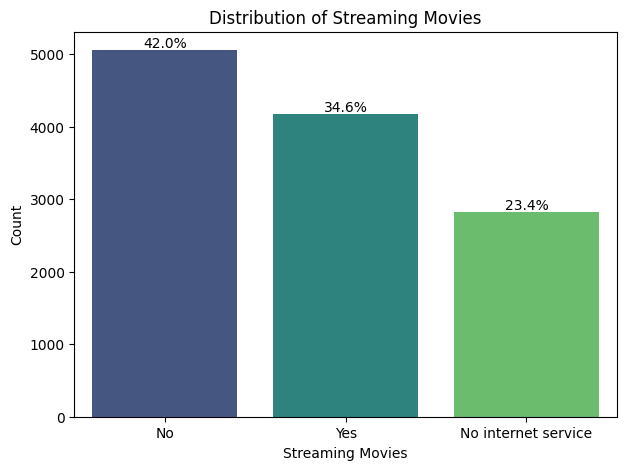

```python
plt.figure(figsize=(7, 5))
ax = sns.countplot(data=Data, x='StreamingMovies', palette='viridis')
plt.title('Distribution of Streaming Movies')
plt.xlabel('Streaming Movies')
plt.ylabel('Count')

total = len(Data['StreamingMovies'])
for p in ax.patches:
    percentage = '{:.1f}%'.format(100 * p.get_height()/total)
    x = p.get_x() + p.get_width() / 2
    y = p.get_height()
    ax.annotate(percentage, (x, y), ha='center', va='bottom')

plt.show()
```

- The distribution of 'StreamingMovies' shows that the 'No' category has the highest count, followed by 'Yes', and then 'No internet service'. This suggests that a significant portion of customers do not subscribe to streaming movie services or do not have internet service at all.

**16. Distribution of 'Contract'**

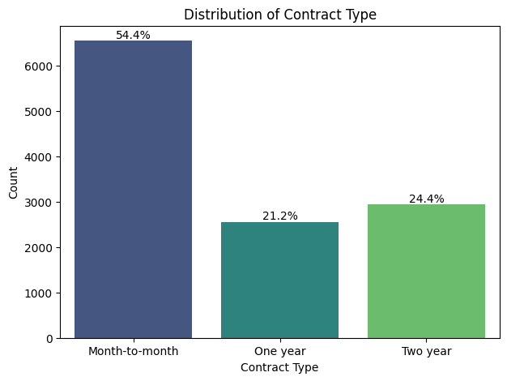

```python
plt.figure(figsize=(7, 5))
ax = sns.countplot(data=Data, x='Contract', palette='viridis')
plt.title('Distribution of Contract Type')
plt.xlabel('Contract Type')
plt.ylabel('Count')

total = len(Data['Contract'])
for p in ax.patches:
    percentage = '{:.1f}%'.format(100 * p.get_height()/total)
    x = p.get_x() + p.get_width() / 2
    y = p.get_height()
    ax.annotate(percentage, (x, y), ha='center', va='bottom')

plt.show()
```

- The distribution of 'Contract' types shows that 'Month-to-month' contracts are the most prevalent, followed by 'Two year' and then 'One year' contracts. This indicates that a significant portion of customers prefer shorter, more flexible contract durations.

**17. Distribution of 'PaperlessBilling'**

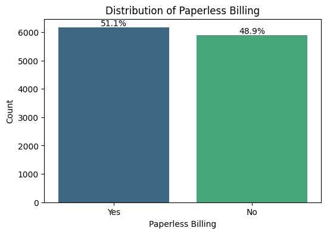

```python
plt.figure(figsize=(6, 4))
ax = sns.countplot(data=Data, x='PaperlessBilling', palette='viridis')
plt.title('Distribution of Paperless Billing')
plt.xlabel('Paperless Billing')
plt.ylabel('Count')

total = len(Data['PaperlessBilling'])
for p in ax.patches:
    percentage = '{:.1f}%'.format(100 * p.get_height()/total)
    x = p.get_x() + p.get_width() / 2
    y = p.get_height()
    ax.annotate(percentage, (x, y), ha='center', va='bottom')

plt.show()
```

- The plot shows that a higher number of customers (51.1%) have opted for paperless billing, while 48.9% have not.

**18. Distribution of 'PaymentMethod'**

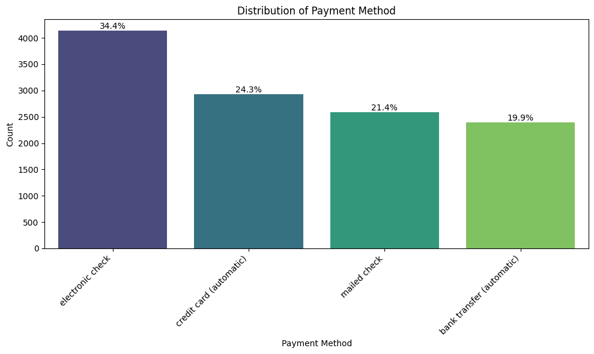

```python
plt.figure(figsize=(10, 6))
ax = sns.countplot(data=Data, x='PaymentMethod', palette='viridis', order=Data['PaymentMethod'].value_counts().index)
plt.title('Distribution of Payment Method')
plt.xlabel('Payment Method')
plt.ylabel('Count')

total = len(Data['PaymentMethod'])
for p in ax.patches:
    percentage = '{:.1f}%'.format(100 * p.get_height()/total)
    x = p.get_x() + p.get_width() / 2
    y = p.get_height()
    ax.annotate(percentage, (x, y), ha='center', va='bottom')

plt.xticks(rotation=45, ha='right')
plt.tight_layout()
plt.show()
```

**19. Distribution of 'MonthlyCharges'**

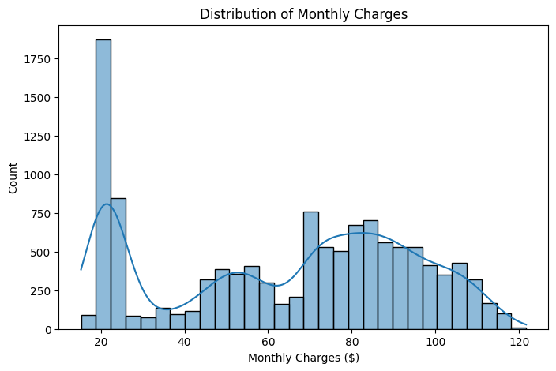

```python
plt.figure(figsize=(8, 5))
sns.histplot(Data['MonthlyCharges'], bins=30, kde=True, palette='viridis')
plt.title('Distribution of Monthly Charges')
plt.xlabel('Monthly Charges ($)')
plt.ylabel('Count')
plt.show()
```

**20. Distribution of 'TotalCharges'**

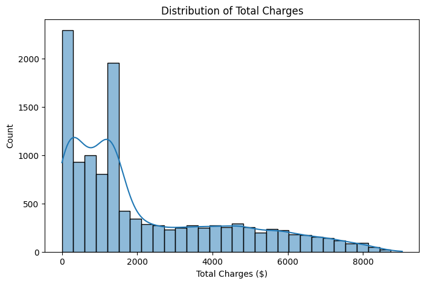

```python
plt.figure(figsize=(8, 5))
sns.histplot(Data['TotalCharges'], bins=30, kde=True, palette='viridis')
plt.title('Distribution of Total Charges')
plt.xlabel('Total Charges ($)')
plt.ylabel('Count')
plt.show()
```

- we can see a right-skewed distribution, indicating that a large number of customers have lower total charges, while fewer customers accumulate very high total charges.

### **Bivariate Analysis**

**1. Churn by Gender**

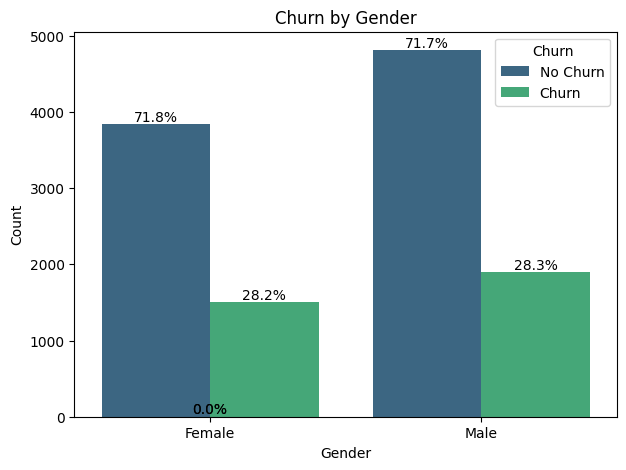

```python
plt.figure(figsize=(7, 5))
ax = sns.countplot(data=Data, x='gender', hue='Churn', palette='viridis')
plt.title('Churn by Gender')
plt.xlabel('Gender')
plt.ylabel('Count')

total_gender_counts = Data['gender'].value_counts()

for p in ax.patches:
    height = p.get_height()
    gender_pos = p.get_x() + p.get_width() / 2

    # Determine which gender this patch corresponds to based on x-position
    if gender_pos < 0.5:  # Assuming 'Female' is at x=0, 'Male' at x=1
        total = total_gender_counts.get('Female', 0)
    else:
        total = total_gender_counts.get('Male', 0)

    if total > 0:
        percentage = '{:.1f}%'.format(100 * height / total)
        ax.annotate(percentage, (gender_pos, height), ha='center', va='bottom')

plt.legend(title='Churn', labels=['No Churn', 'Churn'])
plt.show()
```

- The plot shows that both males and females have a similar churn rate, around 28%. This suggests that gender alone might not be a significant factor in predicting customer churn.

**2. Churn by Senior Citizen**

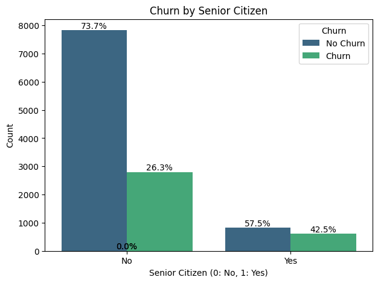

```python
plt.figure(figsize=(7, 5))
ax = sns.countplot(data=Data, x='SeniorCitizen', hue='Churn', palette='viridis')
plt.title('Churn by Senior Citizen')
plt.xlabel('Senior Citizen (0: No, 1: Yes)')
plt.ylabel('Count')
plt.xticks(ticks=[0, 1], labels=['No', 'Yes'])

total_seniorcitizen_counts = Data['SeniorCitizen'].value_counts()

for p in ax.patches:
    height = p.get_height()
    senior_citizen_status = p.get_x() + p.get_width() / 2

    if senior_citizen_status < 0.5:  # Assuming 'No' is at x=0
        total = total_seniorcitizen_counts.get(0, 0)
    else:  # Assuming 'Yes' is at x=1
        total = total_seniorcitizen_counts.get(1, 0)

    if total > 0:
        percentage = '{:.1f}%'.format(100 * height / total)
        ax.annotate(percentage, (p.get_x() + p.get_width() / 2., height), ha='center', va='bottom')

plt.legend(title='Churn', labels=['No Churn', 'Churn'])
plt.show()
```

- The plot reveals that senior citizens have a higher churn rate compared to non-senior citizens. This suggests that being a senior citizen might be a significant factor influencing churn.

**3. Churn by Partner Status**

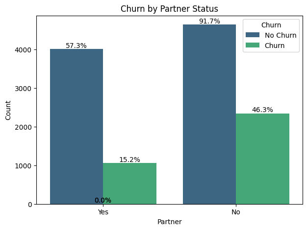

```python
plt.figure(figsize=(7, 5))
ax = sns.countplot(data=Data, x='Partner', hue='Churn', palette='viridis')
plt.title('Churn by Partner Status')
plt.xlabel('Partner')
plt.ylabel('Count')

total_partner_counts = Data['Partner'].value_counts()

for p in ax.patches:
    height = p.get_height()
    partner_status = p.get_x() + p.get_width() / 2

    if partner_status < 0.5:  # Assuming 'No' is at x=0
        total = total_partner_counts.get('No', 0)
    else:  # Assuming 'Yes' is at x=1
        total = total_partner_counts.get('Yes', 0)

    if total > 0:
        percentage = '{:.1f}%'.format(100 * height / total)
        ax.annotate(percentage, (p.get_x() + p.get_width() / 2., height), ha='center', va='bottom')

plt.legend(title='Churn', labels=['No Churn', 'Churn'])
plt.show()
```

- The customers without a partner churn at a higher rate than those with a partner, suggesting that having a partner might indeed contribute to customer loyalty.

**4. Churn by Dependents Status**

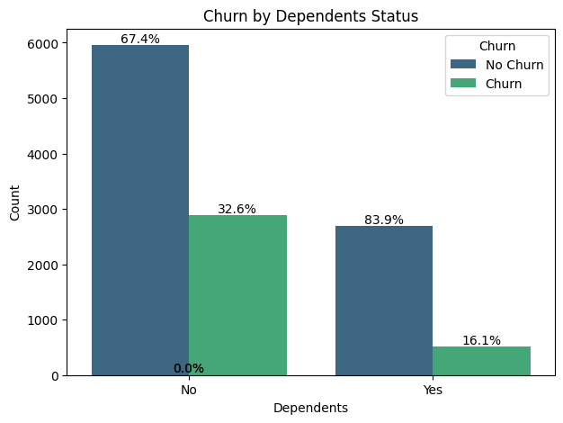

```python
plt.figure(figsize=(7, 5))
ax = sns.countplot(data=Data, x='Dependents', hue='Churn', palette='viridis')
plt.title('Churn by Dependents Status')
plt.xlabel('Dependents')
plt.ylabel('Count')

total_dependents_counts = Data['Dependents'].value_counts()

for p in ax.patches:
    height = p.get_height()
    dependents_status = p.get_x() + p.get_width() / 2

    if dependents_status < 0.5:  # Assuming 'No' is at x=0
        total = total_dependents_counts.get('No', 0)
    else:  # Assuming 'Yes' is at x=1
        total = total_dependents_counts.get('Yes', 0)

    if total > 0:
        percentage = '{:.1f}%'.format(100 * height / total)
        ax.annotate(percentage, (p.get_x() + p.get_width() / 2., height), ha='center', va='bottom')

plt.legend(title='Churn', labels=['No Churn', 'Churn'])
plt.show()
```

- The plot shows that customers who do not have dependents have a significantly higher churn rate compared to those who do have dependents. This indicates that customers with dependents are more likely to remain with the service, suggesting that dependents may be a factor in customer retention.

**5. Churn by Tenure**

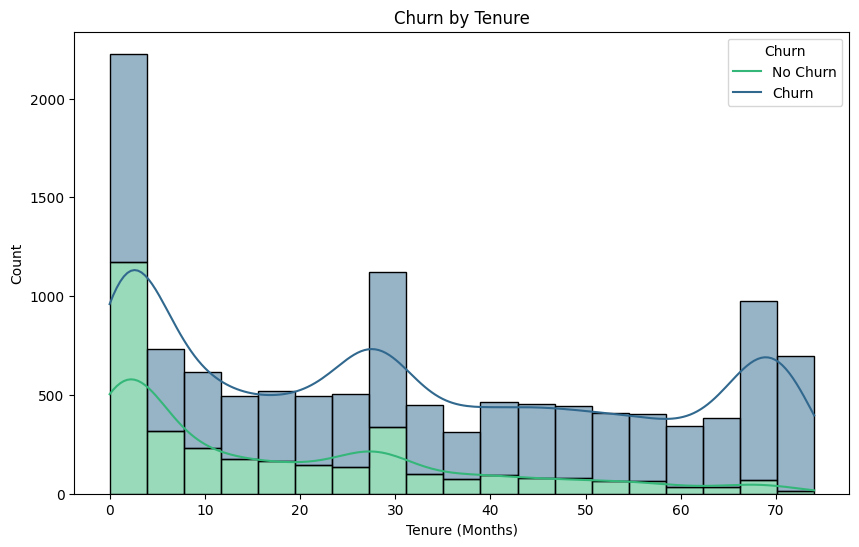

```python
plt.figure(figsize=(10, 6))
sns.histplot(data=Data, x='tenure', hue='Churn', multiple='stack', palette='viridis', kde=True)
plt.title('Churn by Tenure')
plt.xlabel('Tenure (Months)')
plt.ylabel('Count')
plt.legend(title='Churn', labels=['No Churn', 'Churn'])
plt.show()
```

- The histogram shows that a significant portion of churn occurs among customers with very short tenures (0-5 months). As tenure increases, the proportion of churned customers generally decreases, and customers with longer tenures (60-70 months) show a much lower churn rate. This indicates that newer customers are more prone to churn, while long-term customers are more loyal.

**6. Churn by PhoneService**

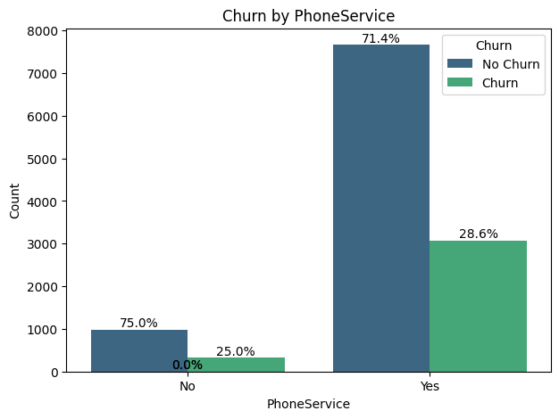

```python
plt.figure(figsize=(7, 5))
ax = sns.countplot(data=Data, x='PhoneService', hue='Churn', palette='viridis')
plt.title('Churn by PhoneService')
plt.xlabel('PhoneService')
plt.ylabel('Count')

total_phoneservice_counts = Data['PhoneService'].value_counts()

for p in ax.patches:
    height = p.get_height()
    phoneservice_status = p.get_x() + p.get_width() / 2

    if phoneservice_status < 0.5:  # Assuming 'No' is at x=0
        total = total_phoneservice_counts.get('No', 0)
    else:  # Assuming 'Yes' is at x=1
        total = total_phoneservice_counts.get('Yes', 0)

    if total > 0:
        percentage = '{:.1f}%'.format(100 * height / total)
        ax.annotate(percentage, (p.get_x() + p.get_width() / 2., height), ha='center', va='bottom')

plt.legend(title='Churn', labels=['No Churn', 'Churn'])
plt.show()
```

- The plot indicates that the presence or absence of phone service does not significantly differentiate churn rates.

**7. Churn by MultipleLines**

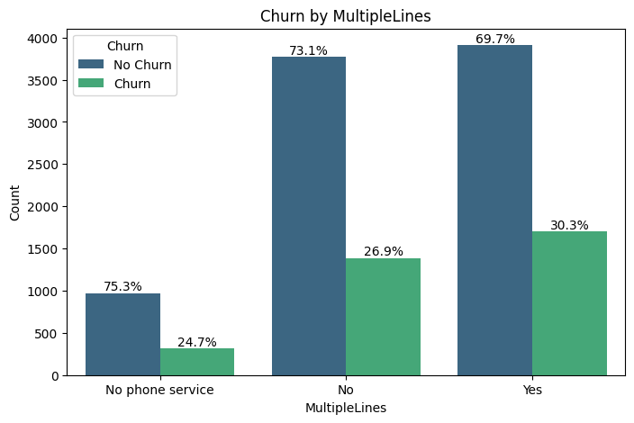

```python
plt.figure(figsize=(8, 5))
ax = sns.countplot(data=Data, x='MultipleLines', hue='Churn', palette='viridis')
plt.title('Churn by MultipleLines')
plt.xlabel('MultipleLines')
plt.ylabel('Count')

# Pre-calculate churn percentages from the Data DataFrame
churn_percentages = Data.groupby('MultipleLines')['Churn'].value_counts(normalize=True).unstack()

# Get the x-tick labels and their positions to map patch x-coordinates to category names
x_tick_positions = ax.get_xticks()
x_tick_labels = [label.get_text() for label in ax.get_xticklabels()]

# Assuming ax.containers[0] holds 'No Churn' bars and ax.containers[1] holds 'Churn' bars
if len(ax.containers) > 1:
    # Iterate over both containers (No Churn and Churn)
    for container_idx, container in enumerate(ax.containers):
        for patch_idx, patch in enumerate(container):
            # Calculate the center x-coordinate of the bar
            bar_center_x = patch.get_x() + patch.get_width() / 2

            # Find the corresponding category label based on the x-coordinate
            # This requires finding the closest x-tick position
            closest_tick_idx = (np.abs(x_tick_positions - bar_center_x)).argmin()
            current_category = x_tick_labels[closest_tick_idx]

            # Get the correct percentage based on container_idx (0 for No Churn, 1 for Churn)
            if current_category in churn_percentages.index:
                percentage_val = churn_percentages.loc[current_category, container_idx] * 100
                ax.annotate(f'{percentage_val:.1f}%',
                            (patch.get_x() + patch.get_width() / 2., patch.get_height()),
                            ha='center', va='bottom', fontsize=10)

plt.legend(title='Churn', labels=['No Churn', 'Churn'])
plt.show()
```

- Customers with 'Yes' (multiple lines) have the highest churn rate at approximately 30.3%.
- Customers with 'No' (single phone line) have a churn rate of about 26.9%.
- Customers with 'No phone service' have the lowest churn rate at around 24.7%.

**8. Churn by InternetService**

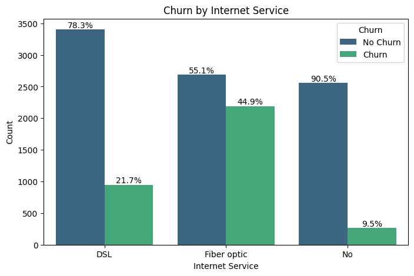

```python
plt.figure(figsize=(8, 5))
ax = sns.countplot(data=Data, x='InternetService', hue='Churn', palette='viridis')
plt.title('Churn by Internet Service')
plt.xlabel('Internet Service')
plt.ylabel('Count')

# Pre-calculate churn percentages
churn_percentages = Data.groupby('InternetService')['Churn'].value_counts(normalize=True).unstack()

# Get the x-tick labels and their positions to map patch x-coordinates to category names
x_tick_positions = ax.get_xticks()
x_tick_labels = [label.get_text() for label in ax.get_xticklabels()]

# Assuming ax.containers[0] holds 'No Churn' bars and ax.containers[1] holds 'Churn' bars
if len(ax.containers) > 1:
    # Iterate over both containers (No Churn and Churn)
    for container_idx, container in enumerate(ax.containers):
        for patch in container:
            # Calculate the center x-coordinate of the bar
            bar_center_x = patch.get_x() + patch.get_width() / 2

            # Find the corresponding category label based on the x-coordinate
            # This requires finding the closest x-tick position
            closest_tick_idx = (np.abs(x_tick_positions - bar_center_x)).argmin()
            current_category = x_tick_labels[closest_tick_idx]

            # Get the correct percentage based on container_idx (0 for No Churn, 1 for Churn)
            if current_category in churn_percentages.index:
                percentage_val = churn_percentages.loc[current_category, container_idx] * 100
                ax.annotate(f'{percentage_val:.1f}%',
                            (patch.get_x() + patch.get_width() / 2., patch.get_height()),
                            ha='center', va='bottom', fontsize=10)

plt.legend(title='Churn', labels=['No Churn', 'Churn'])
plt.show()
```

- Fiber optic internet service has the highest churn rate at approximately 44.9%. This indicates that almost half of the customers using fiber optic churn.
- DSL internet service has a significantly lower churn rate of about 21.7%.
- Customers with No internet service have the lowest churn rate at approximately 9.5%.

This analysis clearly shows that customers with 'Fiber optic' internet service are far more likely to churn than those with 'DSL' or no internet service.

**9. Churn by OnlineSecurity**

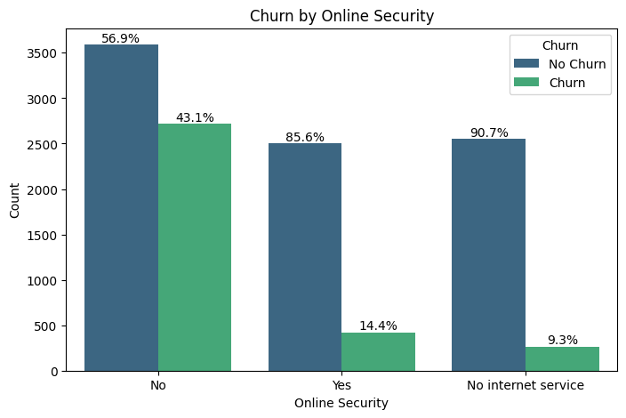

```python
plt.figure(figsize=(8, 5))
ax = sns.countplot(data=Data, x='OnlineSecurity', hue='Churn', palette='viridis')
plt.title('Churn by Online Security')
plt.xlabel('Online Security')
plt.ylabel('Count')

# Pre-calculate churn percentages from the Data DataFrame
churn_percentages = Data.groupby('OnlineSecurity')['Churn'].value_counts(normalize=True).unstack()

# Get the x-tick labels and their positions to map patch x-coordinates to category names
x_tick_positions = ax.get_xticks()
x_tick_labels = [label.get_text() for label in ax.get_xticklabels()]

# Assuming ax.containers[0] holds 'No Churn' bars and ax.containers[1] holds 'Churn' bars
if len(ax.containers) > 1:
    # Iterate over both containers (No Churn and Churn)
    for container_idx, container in enumerate(ax.containers):
        for patch in container:
            # Calculate the center x-coordinate of the bar
            bar_center_x = patch.get_x() + patch.get_width() / 2

            # Find the corresponding category label based on the x-coordinate
            # This requires finding the closest x-tick position
            closest_tick_idx = (np.abs(x_tick_positions - bar_center_x)).argmin()
            current_category = x_tick_labels[closest_tick_idx]

            # Get the correct percentage based on container_idx (0 for No Churn, 1 for Churn)
            if current_category in churn_percentages.index:
                percentage_val = churn_percentages.loc[current_category, container_idx] * 100
                ax.annotate(f'{percentage_val:.1f}%',
                            (patch.get_x() + patch.get_width() / 2., patch.get_height()),
                            ha='center', va='bottom', fontsize=10)

plt.legend(title='Churn', labels=['No Churn', 'Churn'])
plt.show()
```

- Customers with 'No Online Security' have a significantly higher churn rate of approximately 43.1%.
- Customers with 'Yes Online Security' have a much lower churn rate of about 14.4%.
- Customers with 'No internet service' have the lowest churn rate at approximately 9.3%.

This indicates that the presence of online security is a strong factor in customer retention, with customers lacking this service being more prone to churn. Customers who do not have internet service at all are the least likely to churn.

**10. Churn by OnlineBackup**

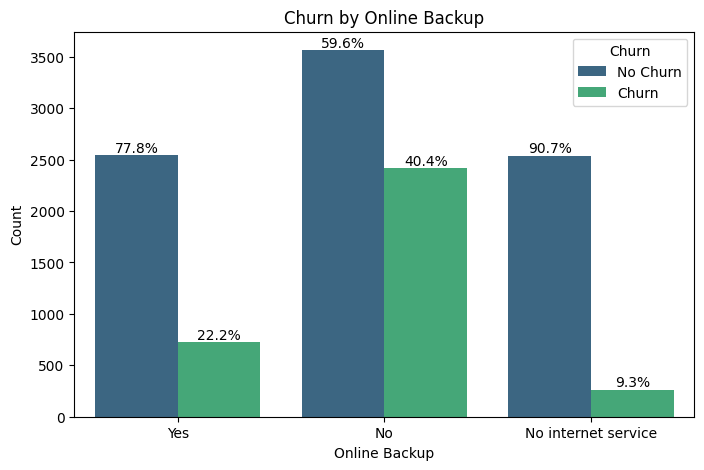

```python
plt.figure(figsize=(8, 5))
ax = sns.countplot(data=Data, x='OnlineBackup', hue='Churn', palette='viridis')
plt.title('Churn by Online Backup')
plt.xlabel('Online Backup')
plt.ylabel('Count')

# Pre-calculate churn percentages from the Data DataFrame
churn_percentages = Data.groupby('OnlineBackup')['Churn'].value_counts(normalize=True).unstack()

# Get the x-tick labels and their positions to map patch x-coordinates to category names
x_tick_positions = ax.get_xticks()
x_tick_labels = [label.get_text() for label in ax.get_xticklabels()]

# Assuming ax.containers[0] holds 'No Churn' bars and ax.containers[1] holds 'Churn' bars
if len(ax.containers) > 1:
    # Iterate over both containers (No Churn and Churn)
    for container_idx, container in enumerate(ax.containers):
        for patch in container:
            # Calculate the center x-coordinate of the bar
            bar_center_x = patch.get_x() + patch.get_width() / 2

            # Find the corresponding category label based on the x-coordinate
            # This requires finding the closest x-tick position
            closest_tick_idx = (np.abs(x_tick_positions - bar_center_x)).argmin()
            current_category = x_tick_labels[closest_tick_idx]

            # Get the correct percentage based on container_idx (0 for No Churn, 1 for Churn)
            if current_category in churn_percentages.index:
                percentage_val = churn_percentages.loc[current_category, container_idx] * 100
                ax.annotate(f'{percentage_val:.1f}%',
                            (patch.get_x() + patch.get_width() / 2., patch.get_height()),
                            ha='center', va='bottom', fontsize=10)

plt.legend(title='Churn', labels=['No Churn', 'Churn'])
plt.show()
```

- Customers with 'No Online Backup' have a significantly higher churn rate of approximately 40.4%.
- Customers with 'Yes Online Backup' have a much lower churn rate of about 22.2%.
- Customers with 'No internet service' have the lowest churn rate at approximately 9.3%.